# plot.matrix

Sigbert Klinke

sigbert@hu-berlin.de

02 Dezember, 2020

# General

The aim of the package `plot.matrix` is to visualize a matrix as is with a heatmap. Automatic reordering of rows and columns is only done if necessary. This is different as in similar function like `heatmap`. Additionally it should be user-friendly and give access to a lot of options if necessary.

Currently the package implements the S3 functions below such that you can use the generic `plot` function to plot matrices as heatmaps:

- `plot.matrix` for a heatmap for a plain matrix,
- `plot.loadings` for a heatmap for a loadings matrix from factor analysis or principal component analysis (reordering of rows!).

The plot itself is composed by a heatmap (usually left) where colors represent matrix entries and a key (usually right) which links the colors to the values.

## First examples

```r
library('plot.matrix')
# numeric matrix
x <- matrix(runif(35), ncol=5) # create a numeric matrix object
class(x)
```

```
#> [1] "matrix" "array"
```

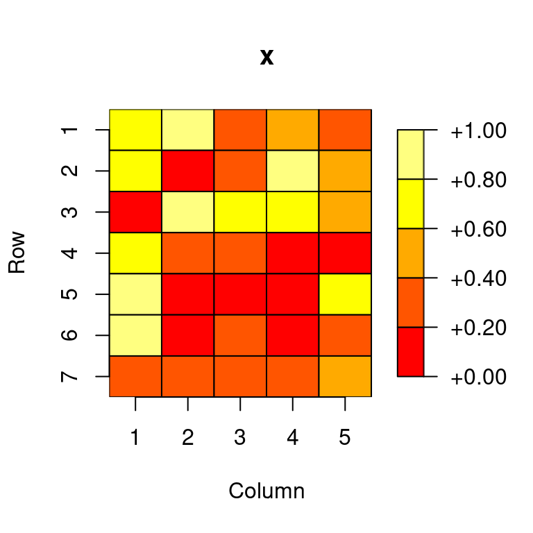

```r
par(mar=c(5.1, 4.1, 4.1, 4.1)) # adapt margins
plot(x)
```

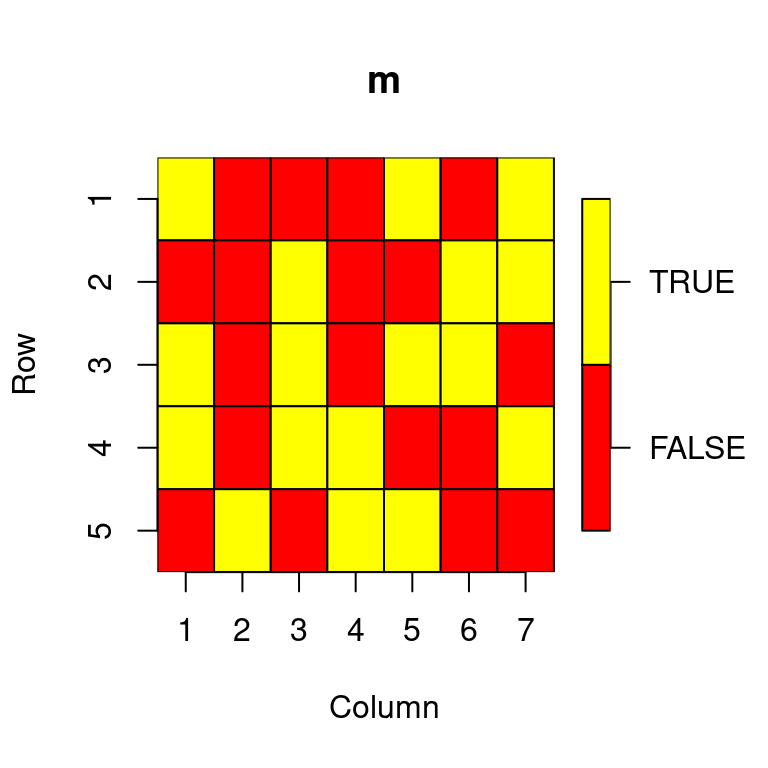

```r
# logical matrix
m <- matrix(runif(35)<0.5, ncol=7)
plot(m)
```

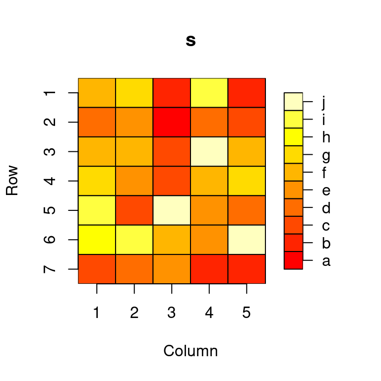

```r
# text matrix
s <- matrix(sample(letters[1:10], 35, replace=TRUE), ncol=5)
plot(s)
```

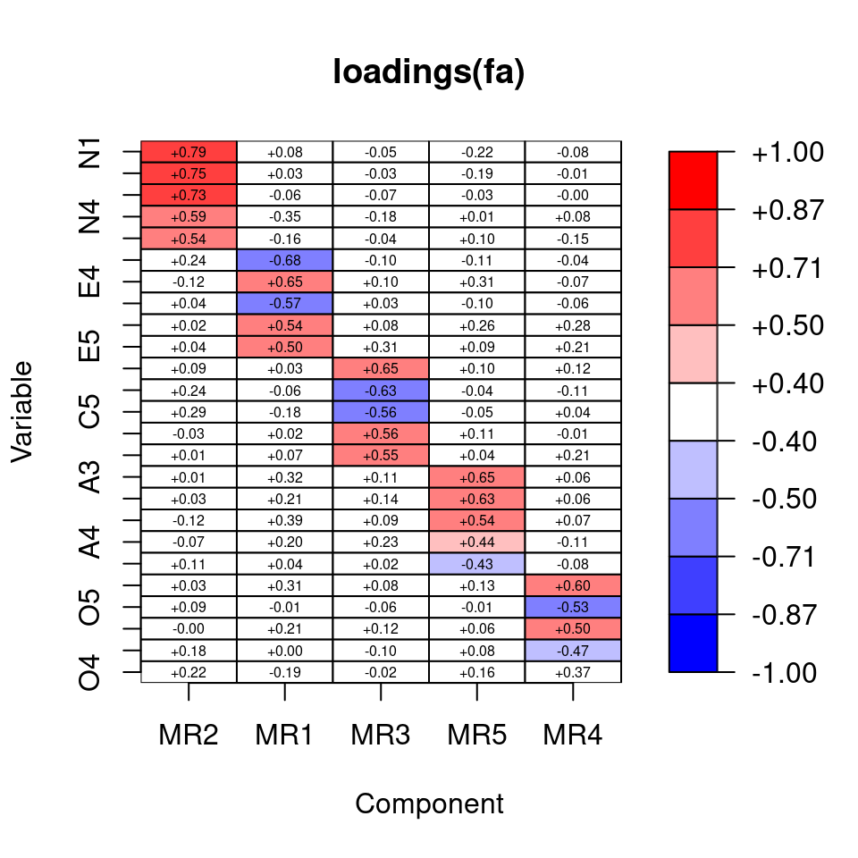

```r
library('plot.matrix')
library('psych')
data <- na.omit(bfi[,1:25])
fa <- fa(data, 5, rotate="varimax")
par(mar=c(5.1, 4.1, 4.1, 4.1)) # adapt margins
plot(loadings(fa), cex=0.5)
```

## Assigning colors and breaks

`plot.matrix` uses the command `assignColors`, also part of `plot.matrix`, assigns to each value in `x` a color based on the parameters `breaks`, `col` and `na.col` given.

In case of a numeric matrix `breaks` can be

- a number, giving the number of intervals covering the range of `x`,
- a vector of two numbers, given the range to cover with 10 intervals, or
- a vector with more than two numbers, specify the interval borders

In case of a non-numeric vector `breaks` must contain all values which are will get a color. If `breaks` is not given then a sensible default is chosen: in case of a numeric vector derived from `pretty` and otherwise all unique values/levels are used.

`col` can be either be a vector of colors or a function which generates via `col(n)` a set of `n` colors. The default is to use `heat.colors`.

## Choosing color palettes/functions

In case that you want to provide your own color palettes/functions for plotting there are several good choices within R packages:

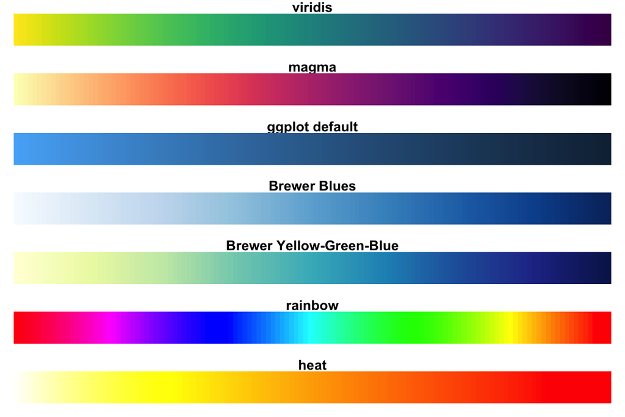

Source: [Datanovia - Top R Color Palettes to Know for Great Data Visualization](https://www.datanovia.com/en/blog/top-r-color-palettes-to-know-for-great-data-visualization/)

- [`viridis`](https://CRAN.R-project.org/package=viridis) or [`viridisLite`](https://CRAN.R-project.org/package=viridisLite),
- [`RColorBrewer`](https://CRAN.R-project.org/package=RColorBrewer),
- [`ggplot2`](https://CRAN.R-project.org/package=ggplot2),
- [`ggsci`](https://CRAN.R-project.org/package=ggsci),
- [`wesanderson`](https://CRAN.R-project.org/package=wesanderson),
- [`cetcolor`](https://CRAN.R-project.org/package=cetcolor),
- [`colormap`](https://CRAN.R-project.org/package=colormap),
- [`ColorPalette`](https://CRAN.R-project.org/package=ColorPalette),
- [`colorr`](https://CRAN.R-project.org/package=colorr),
- [`colorRamps`](https://CRAN.R-project.org/package=colorRamps),
- [`dichromat`](https://CRAN.R-project.org/package=dichromat),
- [`jcolors`](https://CRAN.R-project.org/package=jcolors),
- [`morgenstemning`](https://CRAN.R-project.org/package=morgenstemning),
- [`painter`](https://CRAN.R-project.org/package=painter),
- [`paletteer`](https://CRAN.R-project.org/package=paletteer),
- [`pals`](https://CRAN.R-project.org/package=pals),
- [`Polychrome`](https://CRAN.R-project.org/package=Polychrome),
- [`qualpalr`](https://CRAN.R-project.org/package=qualpalr),
- [`randomcoloR`](https://CRAN.R-project.org/package=randomcoloR), or
- [`Redmonder`](https://CRAN.R-project.org/package=Redmonder).

## Structure of the plot

The plot is created in several steps

1. a call to the `plot` command to create the basic plot
2. draw colored polygons for each matrix entry with the `polygon` command
3. if necessary add the value of each matrix entry with the `text` command in a polygon
4. if necessary draw x- and y-axis with the `axis` command into the plot
5. if necessary draw the key with the `axis` and the `polygon` command

## Formal parameters

| plot.matrix( | x, |  |  |
| --- | --- | --- | --- |
|  | y | = | NULL, |
|  | breaks | = | NULL, |
|  | col | = | heat.colors, |
|  | na.col | = | “white”, |
|  | na.cell | = | TRUE, |
|  | na.print | = | TRUE, |
|  | digits | = | NA, |
|  | fmt.cell | = | NULL, |
|  | fmt.key | = | NULL, |
|  | polygon.cell | = | NULL, |
|  | polygon.key | = | NULL, |
|  | text.cell | = | NULL, |
|  | key | = | list(side = 4, las = 1), |
|  | axis.col | = | list(side = 1), |
|  | axis.row | = | list(side = 2), |
|  | axis.key | = | NULL, |
|  | max.col | = | 70, |
|  | …) |  |  |

You may influence the appearance by setting your own parameters:

1. `...` all parameters given here will be given to the `plot` command, e.g. `xlab`, `ylab`, ….
2. `polygon.cell` list of parameters for drawing polygons for matrix entries
3. `text.cell` list of parameters for putting for matrix entries as texts
4. `axis.col` and `axis.row` list of parameters for drawing for row and column axes
5. `key`, `axis.key` and `polygon.key` to draw the key
6. `max.col` to determine when text color and background color to near

## Set global parameters

You may set global parameters for all subsequent calls of `axis`, `polygon` and `text` via the `...`. The following parameters are supported

| function | parameter(s) |
| --- | --- |
| `axis` | `cex.axis`, `col.axis`, `col.ticks`, `font`, `font.axis`, `hadj`, `las`, `lwd.ticks`, `line` , `outer`, `padj`, `tck`, `tcl`, `tick` |
| `polygon` | `angle`, `border`, `density` |
| `text` | `cex`, `font`, `vfont` |

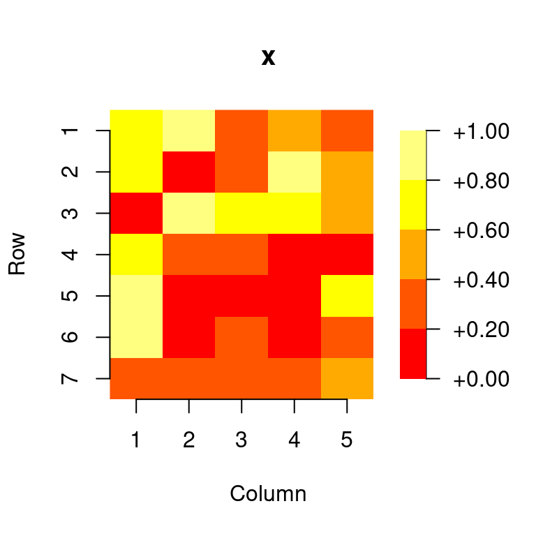

```r
par(mar=c(5.1, 4.1, 4.1, 4.1)) # adapt margins
# omit all borders
plot(x, border=NA)
```

# Frequently asked questions

## How can I delete the grid lines?

Use the parameter `border=NA`.

## How can I get squared boxes?

Use the parameter `asp=TRUE`.

## How can I rotate the axis labels such they do no overlap?

Use the parameter `las`, the style of axis labels, in `axis.col`and/or `axis.row` with

- `0` = always parallel to the axis [default],
- `1` = always horizontal,
- `2` = always perpendicular to the axis, and
- `3` = always vertical.

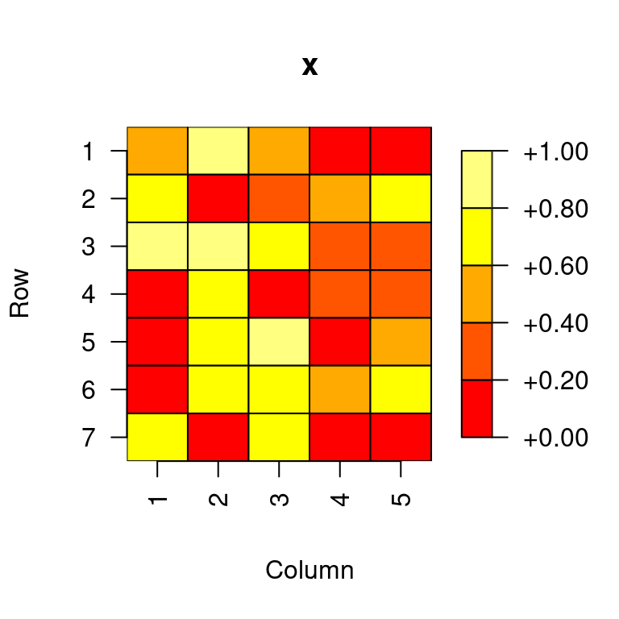

```r
x <- matrix(runif(35), ncol=5) # create a numeric matrix object
par(mar=c(5.1, 4.1, 4.1, 4.1)) # adapt margins such that all labels are visible
plot(x, axis.col=list(side=1, las=2), axis.row = list(side=2, las=1))
```

## How can I show a matrix of parameters and, for example, their standard errors below?

You need to access the position of the cell text used by accessing the invisible return of `plot.matrix`. The `cell.text` contains the parameters used to draw the text.

**Note** the double braces: `[[i,j]]`

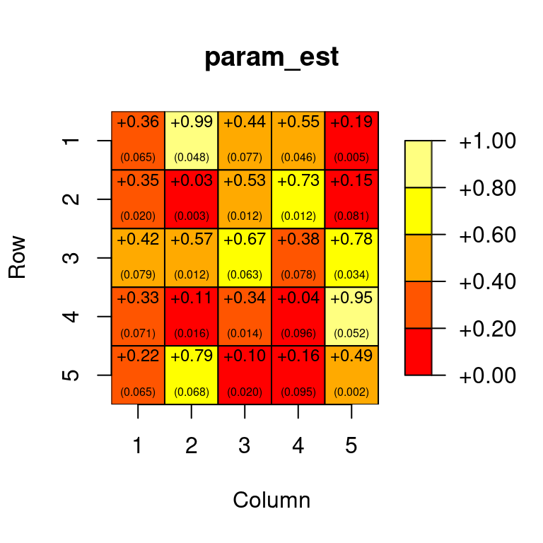

```r
param_est <- matrix(runif(25), nrow=5)
par(mar=c(5.1, 4.1, 4.1, 4.1)) # adapt margins such that all labels are visible
res <- plot(param_est, digits=2, text.cell=list(pos=3, cex=0.75))
sderr_est <- matrix(runif(25)/10, nrow=5)
for (i in 1:nrow(param_est)) {
  for (j in 1:ncol(param_est)) {
    args <- res$cell.text[[i,j]]
    args$labels <- paste0('(', fmt(sderr_est[i,j], 3), ')')
    args$cex    <- 0.5
    args$pos    <- 1
    do.call(text, args)
  }
}
```

Or alternatively

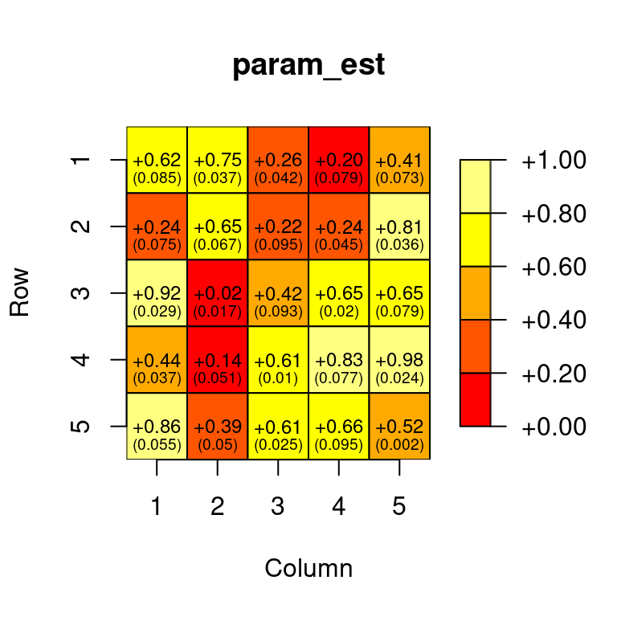

```r
param_est <- matrix(runif(25), nrow=5)
par(mar=c(5.1, 4.1, 4.1, 4.1)) # adapt margins such that all labels are visible
res <- plot(param_est, digits=2, text.cell=list(cex=0.75))
sderr_est <- matrix(runif(25)/10, nrow=5)
for (i in 1:nrow(param_est)) {
  for (j in 1:ncol(param_est)) {
    args <- res$cell.text[[i,j]]
    args$labels <- paste0('(', round(sderr_est[i,j], 3), ')')
    args$cex    <- 0.6
    args$y      <- args$y-0.3
    do.call(text, args)
  }
}
```

# Modifying a plot

## Modifying the breaks

In case of a numeric matrix the `breaks` give the interval borders for a color otherwise for each unique matrix entry `breaks` should contain a value. If `breaks` are not given then they will be determined from the matrix object by using the `pretty` function of base R.

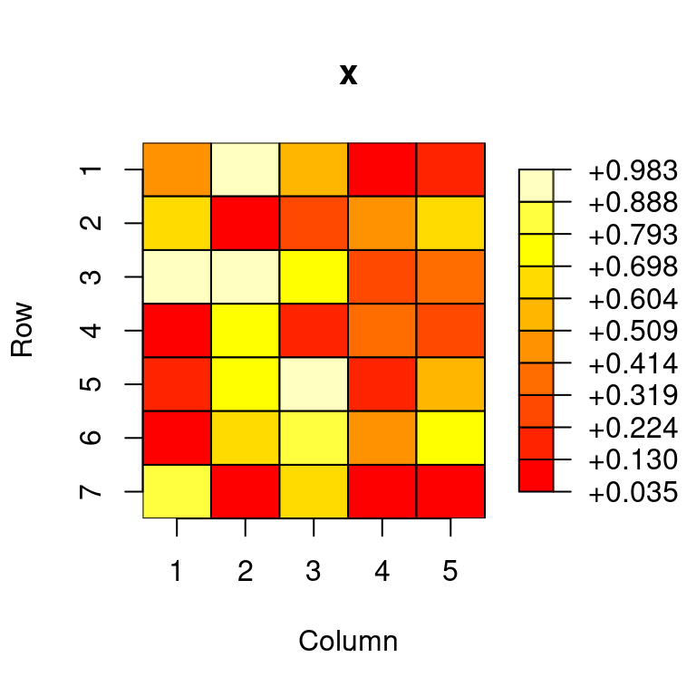

```r
par(mar=c(5.1, 4.1, 4.1, 4.1))   # adapt margins
# we only want the range of x
plot(x, breaks=range(x))
```

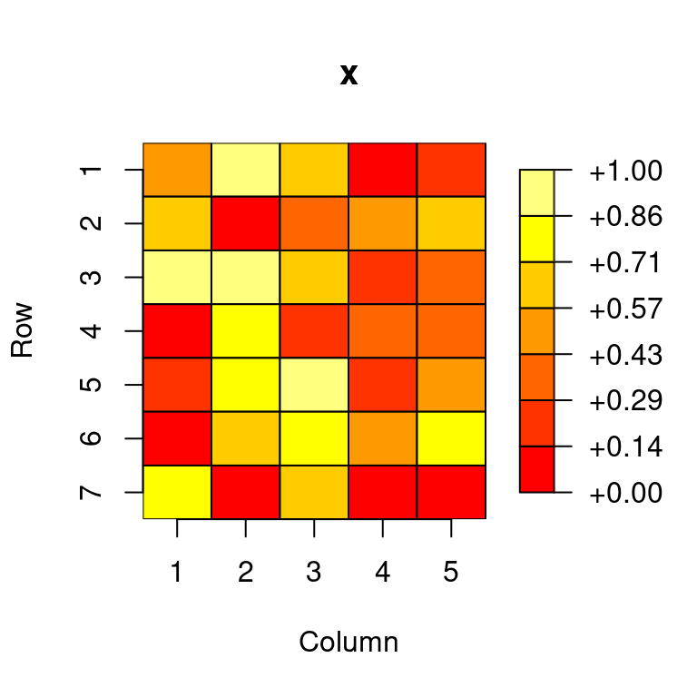

```r
# we want seven colors
plot(x, breaks=7)
```

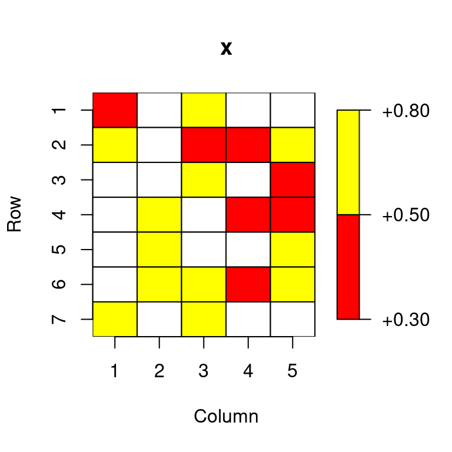

```r
# user defined breaks, out-of-range entries are colored white
plot(x, breaks=c(0.3,0.5,0.8))
```

## Modifying the colors

### Cell colors

The `col` parameter is either a vector of colors used or a function `mycolor(n)` which returns `n` colors on request.

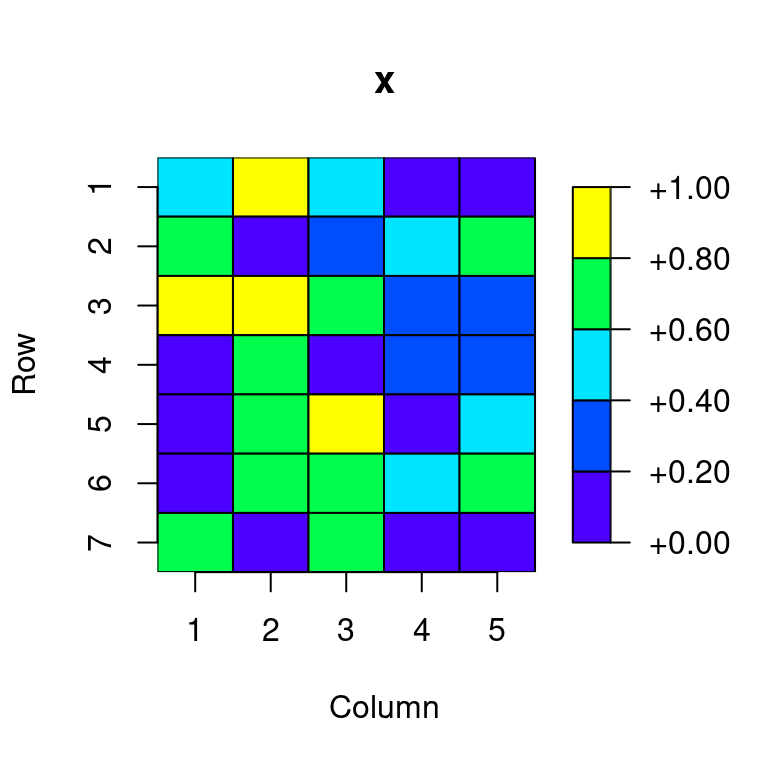

```r
par(mar=c(5.1, 4.1, 4.1, 4.1))   # adapt margins
# use a color function
plot(x, col=topo.colors)
```

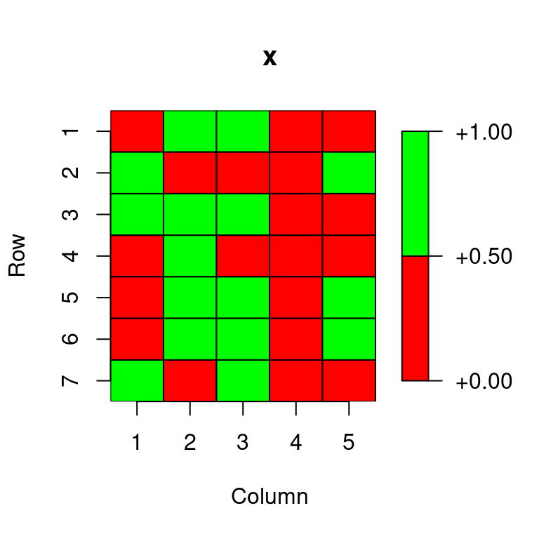

```r
# user defined breaks and colors
plot(x, col=c('red', 'green'), breaks=c(0, 0.5, 1))
```

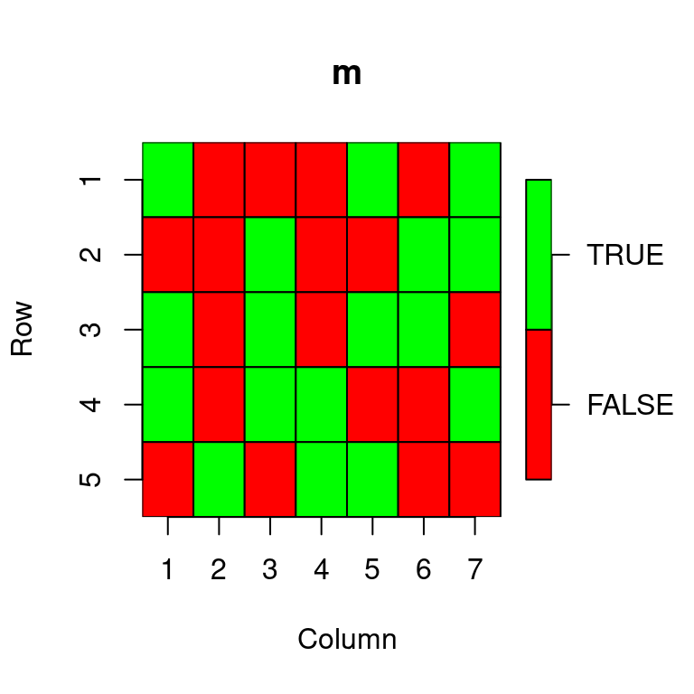

```r
# non-numeric matrix
# assign colors
plot(m, col=c('red', 'green'))
```

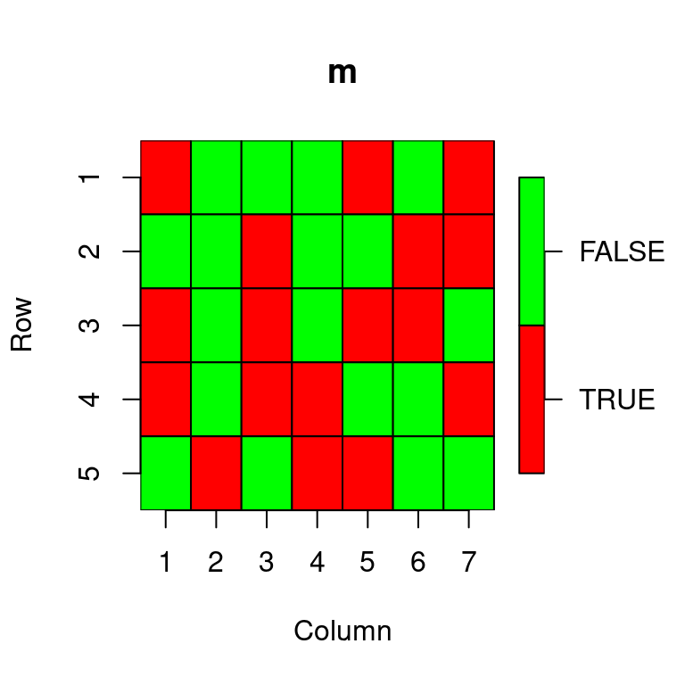

```r
# assign colors and breaks directly
plot(m, col=c('red', 'green'), breaks=c(TRUE, FALSE))
```

Note that for numeric matrices must hold `length(breaks)==length(col)+1` and for non-numeric matrices `length(breaks)==length(col)`.

### Missing values and out-of-range matrix entries

The parameter `na.col` determines the color for missing values and for matrix entries outside the current color scheme.

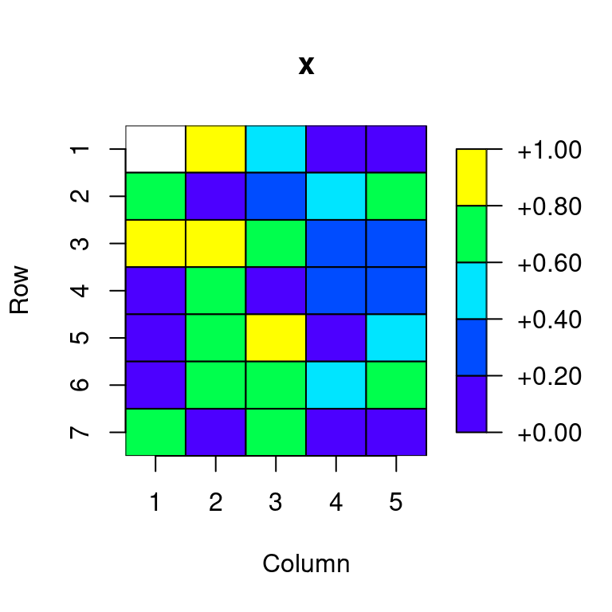

```r
par(mar=c(5.1, 4.1, 4.1, 4.1))   # adapt margins
x[1,1] <- NA
plot(x, col=topo.colors)
```

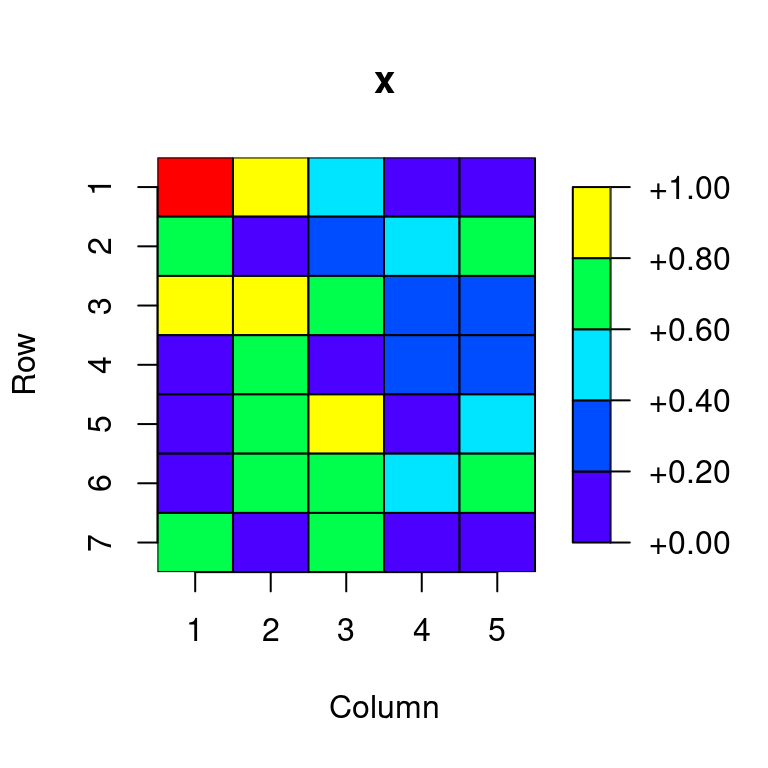

```r
plot(x, col=topo.colors, na.col="red")
```

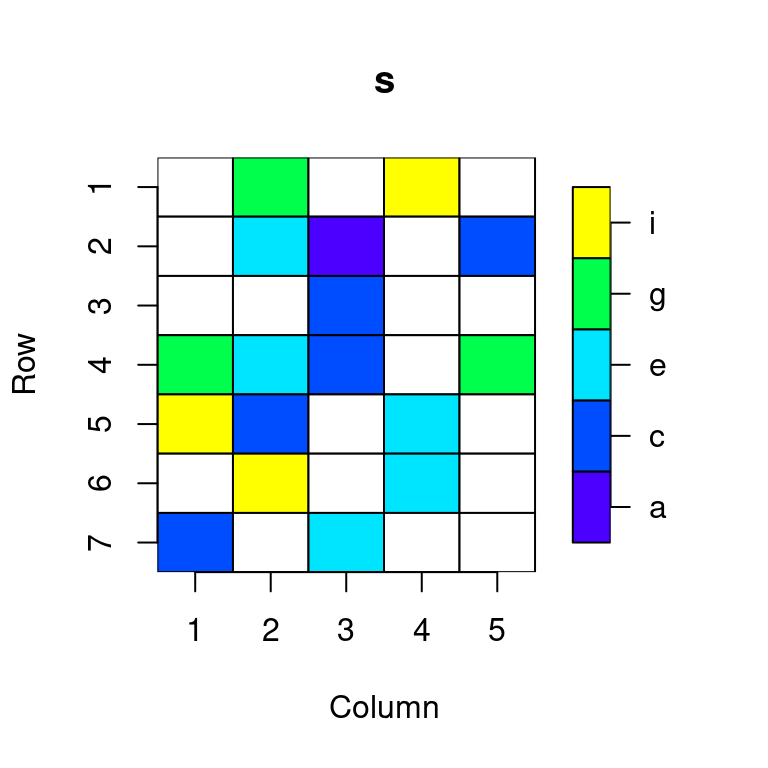

```r
plot(s, col=topo.colors, breaks=c('a', 'c', 'e', 'g', 'i'))
```

## Modifying the key

### Delete the key

For deleting the key set `key=NULL`:

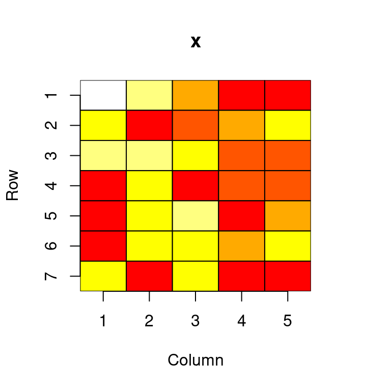

```r
par(mar=c(5.1, 4.1, 4.1, 4.1))   # adapt margins
# delete key
plot(x, key=NULL)
```

### Move the key

For moving the key to a different axis use `key` or `axis.key`. Note that only a warning is issued if the axes for rows, columns or the key are at the same side.

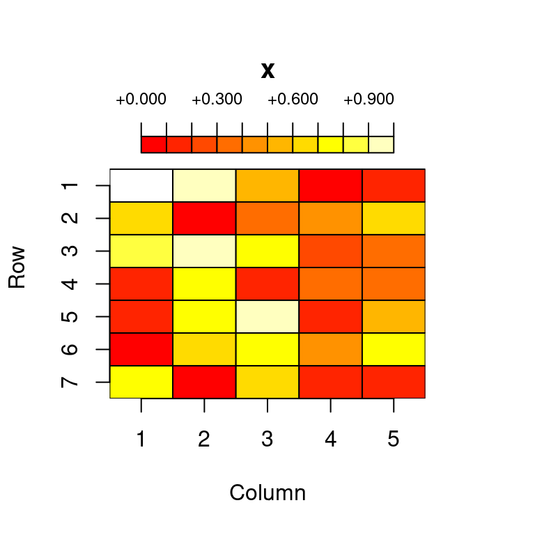

```r
par(mar=c(5.1, 4.1, 5.1, 4.1))   # adapt margins
# move key to the top and make axis text smaller
plot(x, key=list(side=3, cex.axis=0.75), breaks=c(0,1))
```

### Change the output format of the key labels

You can either use `digits` which changes the output format for all text. If you just want to change the output format for the key labels use `fmt.key`, e.g.

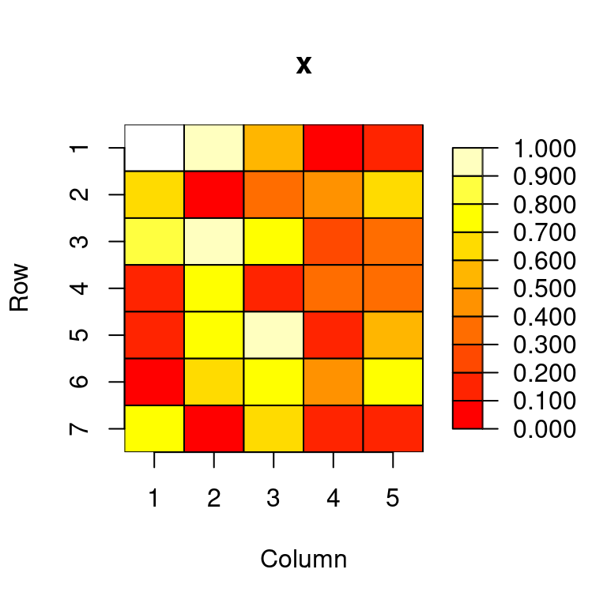

```r
par(mar=c(5.1, 4.1, 4.1, 4.1))   # adapt margins
# no plus sign
plot(x, fmt.key="%.3f", breaks=c(0,1))
```

For details to the format string see `sprintf`, for non-numeric matrices `%s` should be used.

*Warning: The format string is passed down the OS’s sprintf function, and incorrect formats can cause the latter to crash the R process. R does perform sanity checks on the format, but not all possible user errors on all platforms have been tested, and some might be terminal.*

## Modifying the row and column axes

As default the row axis is drawn as y-axis and the col axis is drawn as x-axis with row and column indices. If the matrix has `rownames(x)` or `colnames(x)` then they will used. The same holds for the labels of the axes if `names(dimnames(x))`is not empty.

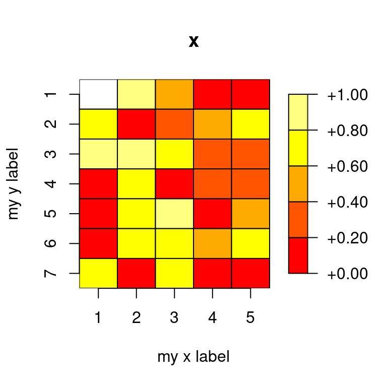

```r
par(mar=c(5.1, 4.1, 4.1, 4.1))   # adapt margins
plot(x, xlab="my x label", ylab="my y label")
```

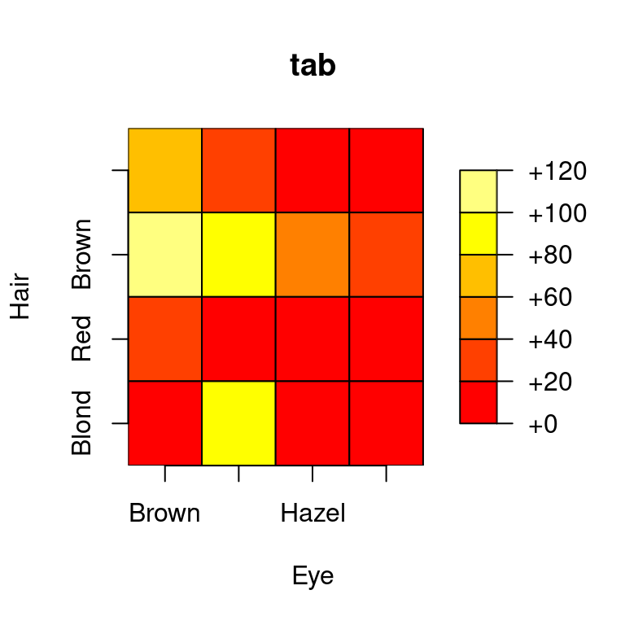

```r
# The HairEyeColor has its own names
tab <- apply(HairEyeColor,1:2, sum)
plot(tab)
```

For moving, e.g. the column axis to the top, use

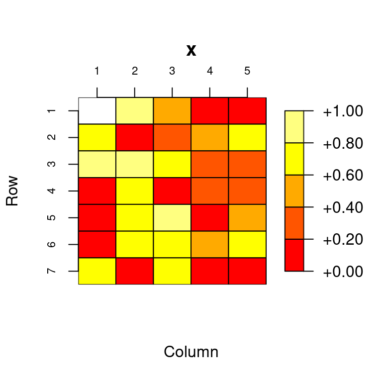

```r
par(mar=c(5.1, 4.1, 5.1, 4.1))   # adapt margins
plot(x, axis.col=list(side=3, cex.axis=0.7), axis.row=list(cex.axis=0.7))
```

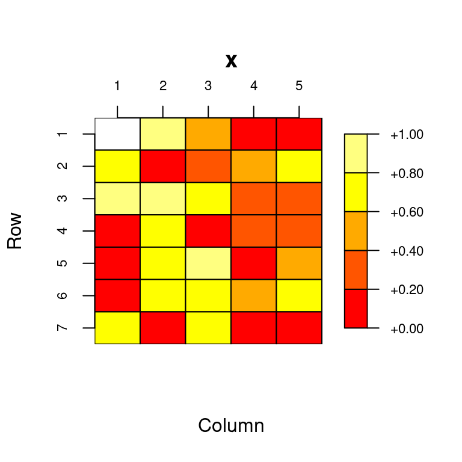

```r
# or alternatively set cex.axis for all axes and use abbreviated positioning
plot(x, axis.col=3, cex.axis=0.7)
```

For not drawing any axes use

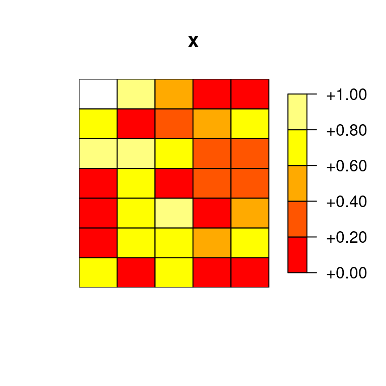

```r
par(mar=c(5.1, 4.1, 4.1, 4.1))   # adapt margins
plot(x, axis.col=NULL, axis.row=NULL, xlab='', ylab='')
```

## Show matrix entries

You can either use `digits` which changes the output format for all text. If you just want to change the output format for the key labels use `fmt.cell`, e.g.

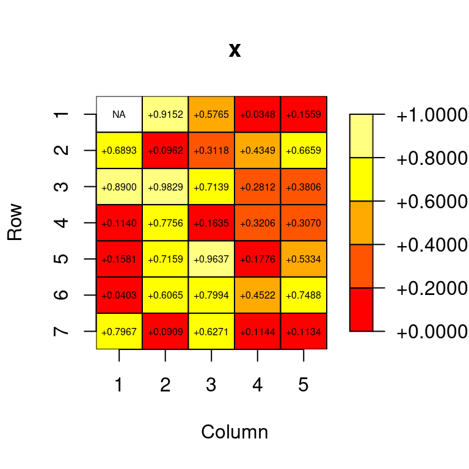

```r
par(mar=c(5.1, 4.1, 4.1, 4.1))   # adapt margins
# change all text output
plot(x, digits=4, text.cell=list(cex=0.5))
```

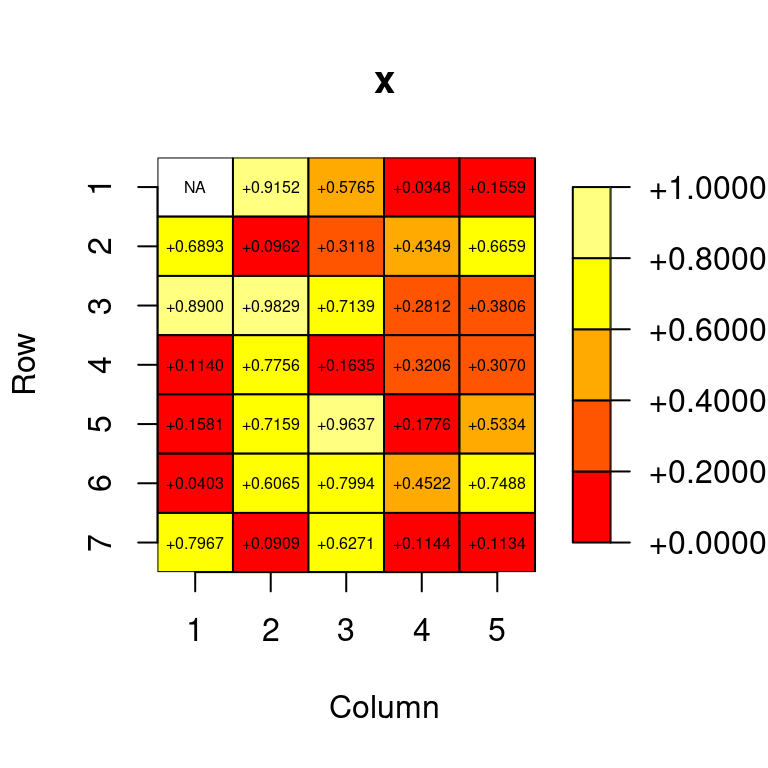

```r
# of alternatively use the global parameter cex
plot(x, digits=4, cex=0.5)
```

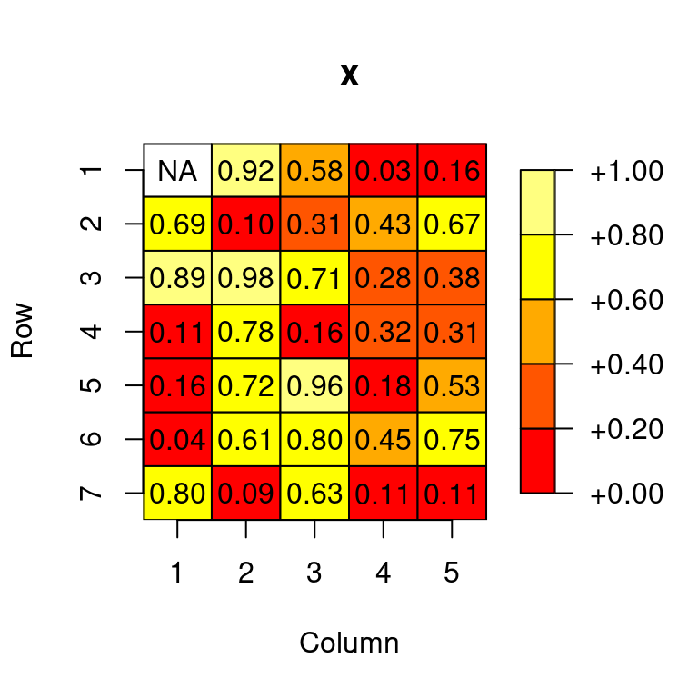

```r
# change just matrix entries (no plus sign)
plot(x, fmt.cell='%.2f')
```